# An example workflow for creating synthetic meter data

Hongyuan Jia

Adrian Chong

2021-07-16

# 1 Building energy model description

In this calibration, we use the U.S. Department of Energy (DOE) medium office reference building model in compliance with Standard ASHRAE 90.1 – 2004.

```r
# path of the model
path <- here("data-raw/idf/RefBldgMediumOfficeNew2004_Chicago.idf")

# read model
model <- read_idf(path)
```

```r
# open a viewer to show 3D building geometry
viewer <- model$view(x_ray = TRUE)

# save a snapshot of current view
snap <- viewer$snapshot(here("figures/3d.png"))

# close the viewer
viewer$close()
```

Fig. 1.1 shows a 3D view of the building geometry. It is a 3-story, 15-zone medium office building with a total floor area of 4982 m^2. A central packaged air conditioning unit with a gas furnace is equipped on each story. The air distribution systems are Variable Air Volume (VAV) terminal boxes with electric reheating coils.

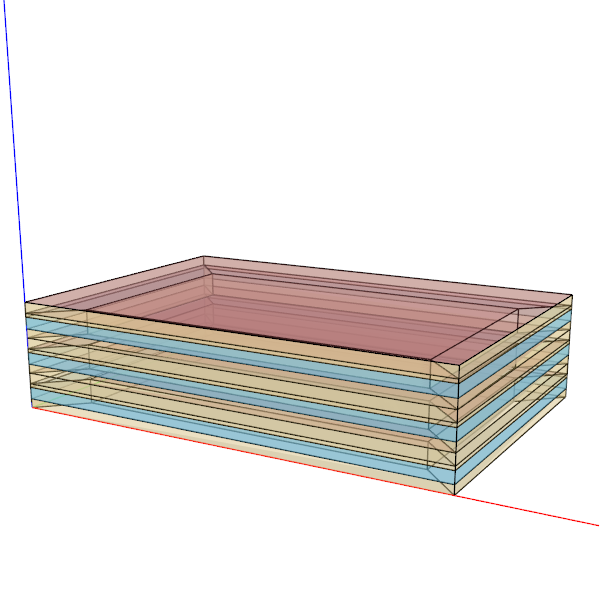

Figure 1.1: 3D view of the medium office reference building model

```r
knitr::include_graphics(here("figures/3d.png"))
```

# 2 Location

The model was built for Chicago, U.S. Since we did not have measured weather data for Chicago, we deciaded to use our Philadelphia 2014 AMY (Actual Meteorological Year) weather file for the synthetic meter data.

# 3 Synthetic data creation

## 3.1 Observed outputs for calibration

For observed output, we choose hourly building electricity consumption. The corresponding output variable in EnergyPlus is `Electricity:Facility` with `Hourly` reporting frequency.

Below we made some necessary to the model, including adding the output meter and setting the begin year of `RunPeriod` objects based on our AMY weather data. We saved the modifed model as `Synthetic.idf` in the `data/idf` folder.

```r
# remove all existing outputs
model$`Output:Variable` <- NULL
model$`Output:Meter` <- NULL

# add hourly building electricity output meter
model$add(Output_Meter = list("Electricity:Facility", "Hourly"))

# make sure weater file is used
model$SimulationControl$Run_Simulation_for_Weather_File_Run_Periods <- "Yes"

# update RunPeriod to correctly indicate an AMY EPW file is used
model$RunPeriod$annual$set(
    name = "Philadelphia 2014",
    begin_year = 2014,
    day_of_week_for_start_day = "Wednesday"
)

# save the model
model$save(here("data/idf/Synthetic.idf"), overwrite = TRUE)
```

## 3.2 Run simulation to create synthetic data

Next, we run the model using AMY EPW file to create synthetic observed output. The data will present noise-free measurements which functions as a surrogate for clean sensor data.

Below we ran an annual simulation using the AMY EPW stored in `data-raw/epw/AMY` folder.

```r
# path of AMY EPW
path_epw_amy <- here("data-raw/epw/AMY/PA_PHILADELPHIA_720304_14-13.epw")

# run annual simulation for AMY
model$run(path_epw_amy, here("data/sim/Synthetic"), echo = FALSE)
```

Once the simulation completed, we extracted the output using `$report_data()` method, convert the unit of electricity from Joules to kWh and save the values together with the timestamp to a csv file named `synthetic_meter.csv` in the `data` folder.

```r
synthetic_meter <- model %>% extract_electricity()

# save synthetic meter data
write_csv(synthetic_meter, here("data/synthetic_meter.csv"))
```